# Week 4

```python
# First Import these files

from __future__ import print_function, division
import numpy as np
import nsfg
```

```python
#nsfg.ReadFemPreg() this module's function reads the NSFG pregnancy dataand return a dataframe
preg = nsfg.ReadFemPreg()
```

```python
#Count the number of times each value occurs.
#Search Documentations of value_counts() and sort_index()

preg.outcome.value_counts().sort_index()
#preg.birthwgt_lb.value_counts().sort_index()

# .isnull()
#preg.birthord.isnull()
#preg.birthord.isnull().value_counts()
#preg.birthord.isnull().sum()

#statistics
#preg.describe()
#preg.basewgt.min()
#preg.basewgt.mean()
#preg.mean()
```

```
1    9148
2    1862
3     120
4    1921
5     190
6     352
Name: outcome, dtype: int64
```

## Coming Back to our topics

#### Given a list of values, there are several ways to count the frequency of each value.

```python
t = [1, 2, 2, 3, 5,3,2,1,2,5,2]
```

You can use a Python dictionary:

```python
hist = {}
for x in t:
    hist[x] = hist.get(x, 0) + 1

hist
```

```
{1: 2, 2: 5, 3: 2, 5: 2}
```

You can use a Counter (which is a dictionary with additional methods):

```python
t
```

```
[1, 2, 2, 3, 5, 3, 2, 1, 2, 5, 2]
```

```python
from collections import Counter
counter = Counter(t)
counter
```

```
Counter({1: 2, 2: 5, 3: 2, 5: 2})
```

Or you can use the Hist object provided by thinkstats2:

```python
import thinkstats2
hist = thinkstats2.Hist(t)
hist
```

```
Hist({1: 2, 2: 5, 3: 2, 5: 2})
```

Hist provides Freq, which looks up the frequency of a value.

```python
hist.Freq(2)
```

```
5
```

You can also use the bracket operator, which does the same thing.

If the value does not appear, it has frequency 0.

```python
print(hist[2])
print(hist[4])
```

```
5
0
```

The Values method returns the values:

```python
hist
```

```
Hist({1: 2, 2: 5, 3: 2, 5: 2})
```

So you can iterate the values and their frequencies like this:

```python
for val in sorted(hist.Values()):
    print(val, hist[val])
```

```
1 2
2 5
3 2
5 2
```

Or you can use the Items method:

```python
for val, freq in hist.Items():
     print(val, freq)
```

```
1 2
2 5
3 2
5 2
```

thinkplot is a wrapper for matplotlib that provides functions that work with the objects in thinkstats2.

For example Hist plots the values and their frequencies as a bar graph.

Config takes parameters that label the x and y axes, among other things.

```python
hist
```

```
Hist({1: 2, 2: 5, 3: 2, 5: 2})
```

```
No handlers could be found for logger "matplotlib.legend"
```

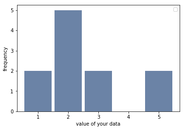

```python
import thinkplot
thinkplot.Hist(hist)
thinkplot.Config(xlabel='value of your data', ylabel='frequency')
```

First, I'll load the data from the pregnancy file and select the records for live births.

```python
preg = nsfg.ReadFemPreg()
preg.head(20)
```

|  | caseid | pregordr | howpreg_n | howpreg_p | moscurrp | nowprgdk | pregend1 | pregend2 | nbrnaliv | multbrth | ... | laborfor_i | religion_i | metro_i | basewgt | adj_mod_basewgt | finalwgt | secu_p | sest | cmintvw | totalwgt_lb |
| --- | --- | --- | --- | --- | --- | --- | --- | --- | --- | --- | --- | --- | --- | --- | --- | --- | --- | --- | --- | --- | --- |
| 0 | 1 | 1 | NaN | NaN | NaN | NaN | 6.0 | NaN | 1.0 | NaN | ... | 0 | 0 | 0 | 3410.389399 | 3869.349602 | 6448.271112 | 2 | 9 | NaN | 8.8125 |
| 1 | 1 | 2 | NaN | NaN | NaN | NaN | 6.0 | NaN | 1.0 | NaN | ... | 0 | 0 | 0 | 3410.389399 | 3869.349602 | 6448.271112 | 2 | 9 | NaN | 7.8750 |
| 2 | 2 | 1 | NaN | NaN | NaN | NaN | 5.0 | NaN | 3.0 | 5.0 | ... | 0 | 0 | 0 | 7226.301740 | 8567.549110 | 12999.542264 | 2 | 12 | NaN | 9.1250 |
| 3 | 2 | 2 | NaN | NaN | NaN | NaN | 6.0 | NaN | 1.0 | NaN | ... | 0 | 0 | 0 | 7226.301740 | 8567.549110 | 12999.542264 | 2 | 12 | NaN | 7.0000 |
| 4 | 2 | 3 | NaN | NaN | NaN | NaN | 6.0 | NaN | 1.0 | NaN | ... | 0 | 0 | 0 | 7226.301740 | 8567.549110 | 12999.542264 | 2 | 12 | NaN | 6.1875 |
| 5 | 6 | 1 | NaN | NaN | NaN | NaN | 6.0 | NaN | 1.0 | NaN | ... | 0 | 0 | 0 | 4870.926435 | 5325.196999 | 8874.440799 | 1 | 23 | NaN | 8.5625 |
| 6 | 6 | 2 | NaN | NaN | NaN | NaN | 6.0 | NaN | 1.0 | NaN | ... | 0 | 0 | 0 | 4870.926435 | 5325.196999 | 8874.440799 | 1 | 23 | NaN | 9.5625 |
| 7 | 6 | 3 | NaN | NaN | NaN | NaN | 6.0 | NaN | 1.0 | NaN | ... | 0 | 0 | 0 | 4870.926435 | 5325.196999 | 8874.440799 | 1 | 23 | NaN | 8.3750 |
| 8 | 7 | 1 | NaN | NaN | NaN | NaN | 5.0 | NaN | 1.0 | NaN | ... | 0 | 0 | 0 | 3409.579565 | 3787.539000 | 6911.879921 | 2 | 14 | NaN | 7.5625 |
| 9 | 7 | 2 | NaN | NaN | NaN | NaN | 5.0 | NaN | 1.0 | NaN | ... | 0 | 0 | 0 | 3409.579565 | 3787.539000 | 6911.879921 | 2 | 14 | NaN | 6.6250 |
| 10 | 12 | 1 | NaN | NaN | NaN | NaN | 5.0 | NaN | 1.0 | NaN | ... | 0 | 0 | 0 | 3612.781968 | 4146.013572 | 6909.331618 | 1 | 31 | NaN | 7.8125 |
| 11 | 14 | 1 | NaN | NaN | NaN | NaN | 6.0 | NaN | 1.0 | NaN | ... | 0 | 0 | 0 | 2418.069494 | 2810.302771 | 3039.904507 | 2 | 56 | NaN | 7.0000 |
| 12 | 14 | 2 | NaN | NaN | NaN | NaN | 6.0 | NaN | 1.0 | NaN | ... | 0 | 0 | 0 | 2418.069494 | 2810.302771 | 3039.904507 | 2 | 56 | NaN | 4.0000 |
| 13 | 14 | 3 | NaN | NaN | NaN | NaN | 3.0 | NaN | NaN | NaN | ... | 0 | 0 | 0 | 2418.069494 | 2810.302771 | 3039.904507 | 2 | 56 | NaN | NaN |
| 14 | 15 | 1 | NaN | NaN | NaN | NaN | 1.0 | NaN | NaN | NaN | ... | 0 | 0 | 0 | 1667.816099 | 3200.862017 | 5553.495599 | 1 | 33 | NaN | NaN |
| 15 | 15 | 2 | NaN | NaN | NaN | NaN | 6.0 | NaN | 1.0 | NaN | ... | 0 | 0 | 0 | 1667.816099 | 3200.862017 | 5553.495599 | 1 | 33 | NaN | 7.6875 |
| 16 | 15 | 3 | NaN | NaN | NaN | NaN | 6.0 | NaN | 1.0 | NaN | ... | 0 | 0 | 0 | 1667.816099 | 3200.862017 | 5553.495599 | 1 | 33 | NaN | 7.5000 |
| 17 | 18 | 1 | NaN | NaN | NaN | NaN | 5.0 | NaN | 1.0 | NaN | ... | 0 | 0 | 0 | 2957.257457 | 3404.403067 | 4153.371741 | 2 | 14 | NaN | 6.3125 |
| 18 | 18 | 2 | NaN | NaN | NaN | NaN | 1.0 | NaN | NaN | NaN | ... | 0 | 0 | 0 | 2957.257457 | 3404.403067 | 4153.371741 | 2 | 14 | NaN | NaN |
| 19 | 21 | 1 | NaN | NaN | NaN | NaN | 6.0 | NaN | 1.0 | NaN | ... | 0 | 0 | 0 | 3408.342437 | 3965.763949 | 7237.122630 | 1 | 48 | NaN | 8.7500 |

20 rows × 244 columns

Here's the histogram of birth weights in pounds. Notice that Hist works with anything iterable, including a Pandas Series. The label attribute appears in the legend when you plot the Hist

```python
live = preg[preg.outcome == 1]
live.head(20)
```

|  | caseid | pregordr | howpreg_n | howpreg_p | moscurrp | nowprgdk | pregend1 | pregend2 | nbrnaliv | multbrth | ... | laborfor_i | religion_i | metro_i | basewgt | adj_mod_basewgt | finalwgt | secu_p | sest | cmintvw | totalwgt_lb |
| --- | --- | --- | --- | --- | --- | --- | --- | --- | --- | --- | --- | --- | --- | --- | --- | --- | --- | --- | --- | --- | --- |
| 0 | 1 | 1 | NaN | NaN | NaN | NaN | 6.0 | NaN | 1.0 | NaN | ... | 0 | 0 | 0 | 3410.389399 | 3869.349602 | 6448.271112 | 2 | 9 | NaN | 8.8125 |
| 1 | 1 | 2 | NaN | NaN | NaN | NaN | 6.0 | NaN | 1.0 | NaN | ... | 0 | 0 | 0 | 3410.389399 | 3869.349602 | 6448.271112 | 2 | 9 | NaN | 7.8750 |
| 2 | 2 | 1 | NaN | NaN | NaN | NaN | 5.0 | NaN | 3.0 | 5.0 | ... | 0 | 0 | 0 | 7226.301740 | 8567.549110 | 12999.542264 | 2 | 12 | NaN | 9.1250 |
| 3 | 2 | 2 | NaN | NaN | NaN | NaN | 6.0 | NaN | 1.0 | NaN | ... | 0 | 0 | 0 | 7226.301740 | 8567.549110 | 12999.542264 | 2 | 12 | NaN | 7.0000 |
| 4 | 2 | 3 | NaN | NaN | NaN | NaN | 6.0 | NaN | 1.0 | NaN | ... | 0 | 0 | 0 | 7226.301740 | 8567.549110 | 12999.542264 | 2 | 12 | NaN | 6.1875 |
| 5 | 6 | 1 | NaN | NaN | NaN | NaN | 6.0 | NaN | 1.0 | NaN | ... | 0 | 0 | 0 | 4870.926435 | 5325.196999 | 8874.440799 | 1 | 23 | NaN | 8.5625 |
| 6 | 6 | 2 | NaN | NaN | NaN | NaN | 6.0 | NaN | 1.0 | NaN | ... | 0 | 0 | 0 | 4870.926435 | 5325.196999 | 8874.440799 | 1 | 23 | NaN | 9.5625 |
| 7 | 6 | 3 | NaN | NaN | NaN | NaN | 6.0 | NaN | 1.0 | NaN | ... | 0 | 0 | 0 | 4870.926435 | 5325.196999 | 8874.440799 | 1 | 23 | NaN | 8.3750 |
| 8 | 7 | 1 | NaN | NaN | NaN | NaN | 5.0 | NaN | 1.0 | NaN | ... | 0 | 0 | 0 | 3409.579565 | 3787.539000 | 6911.879921 | 2 | 14 | NaN | 7.5625 |
| 9 | 7 | 2 | NaN | NaN | NaN | NaN | 5.0 | NaN | 1.0 | NaN | ... | 0 | 0 | 0 | 3409.579565 | 3787.539000 | 6911.879921 | 2 | 14 | NaN | 6.6250 |
| 10 | 12 | 1 | NaN | NaN | NaN | NaN | 5.0 | NaN | 1.0 | NaN | ... | 0 | 0 | 0 | 3612.781968 | 4146.013572 | 6909.331618 | 1 | 31 | NaN | 7.8125 |
| 11 | 14 | 1 | NaN | NaN | NaN | NaN | 6.0 | NaN | 1.0 | NaN | ... | 0 | 0 | 0 | 2418.069494 | 2810.302771 | 3039.904507 | 2 | 56 | NaN | 7.0000 |
| 12 | 14 | 2 | NaN | NaN | NaN | NaN | 6.0 | NaN | 1.0 | NaN | ... | 0 | 0 | 0 | 2418.069494 | 2810.302771 | 3039.904507 | 2 | 56 | NaN | 4.0000 |
| 15 | 15 | 2 | NaN | NaN | NaN | NaN | 6.0 | NaN | 1.0 | NaN | ... | 0 | 0 | 0 | 1667.816099 | 3200.862017 | 5553.495599 | 1 | 33 | NaN | 7.6875 |
| 16 | 15 | 3 | NaN | NaN | NaN | NaN | 6.0 | NaN | 1.0 | NaN | ... | 0 | 0 | 0 | 1667.816099 | 3200.862017 | 5553.495599 | 1 | 33 | NaN | 7.5000 |
| 17 | 18 | 1 | NaN | NaN | NaN | NaN | 5.0 | NaN | 1.0 | NaN | ... | 0 | 0 | 0 | 2957.257457 | 3404.403067 | 4153.371741 | 2 | 14 | NaN | 6.3125 |
| 19 | 21 | 1 | NaN | NaN | NaN | NaN | 6.0 | NaN | 1.0 | NaN | ... | 0 | 0 | 0 | 3408.342437 | 3965.763949 | 7237.122630 | 1 | 48 | NaN | 8.7500 |
| 20 | 21 | 2 | NaN | NaN | NaN | NaN | 6.0 | NaN | 1.0 | NaN | ... | 0 | 0 | 0 | 3408.342437 | 3965.763949 | 7237.122630 | 1 | 48 | NaN | 8.1875 |
| 21 | 23 | 1 | NaN | NaN | NaN | NaN | 6.0 | NaN | 1.0 | NaN | ... | 0 | 0 | 0 | 6210.373020 | 8120.841310 | 13533.382043 | 2 | 64 | NaN | 5.5625 |
| 23 | 24 | 1 | NaN | NaN | NaN | NaN | 6.0 | NaN | 1.0 | NaN | ... | 0 | 0 | 0 | 3409.573258 | 4068.628645 | 7424.840414 | 1 | 27 | NaN | 6.7500 |

20 rows × 244 columns

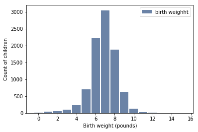

```python
hist = thinkstats2.Hist(live.birthwgt_lb, label='birth weighht')
#print(hist)
thinkplot.Hist(hist)
thinkplot.Config(xlabel='Birth weight (pounds)', ylabel='Count of children')
```

Before plotting the ages, I'll apply floor to round down:

```python
ages = np.floor(live.agepreg)
ages
```

```
0        33.0
1        39.0
2        14.0
3        17.0
4        18.0
5        27.0
6        28.0
7        30.0
8        28.0
9        32.0
10       25.0
11       23.0
12       24.0
15       28.0
16       30.0
```

[output cut: 47 more lines]

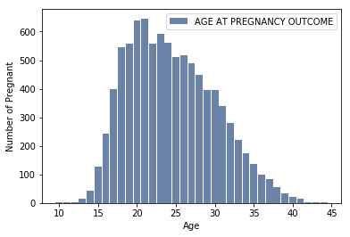

```python
hist = thinkstats2.Hist(ages, label='AGE AT PREGNANCY OUTCOME')
thinkplot.Hist(hist)
thinkplot.Config(xlabel='Age', ylabel='Number of Pregnant')
```

```python
print(hist)
```

```
Hist({10.0: 2, 11.0: 1, 12.0: 1, 13.0: 14, 14.0: 43, 15.0: 128, 16.0: 242, 17.0: 398, 18.0: 546, 19.0: 559, 20.0: 638, 21.0: 646, 22.0: 557, 23.0: 593, 24.0: 561, 25.0: 512, 26.0: 517, 27.0: 489, 28.0: 449, 29.0: 395, 30.0: 396, 31.0: 339, 32.0: 279, 33.0: 220, 34.0: 175, 35.0: 138, 36.0: 99, 37.0: …
```

Hist provides smallest, which select the lowest values and their frequencies.

```python
for weeks, freq in hist.Smallest(10):
    print(weeks, freq)
```

```
10.0 2
11.0 1
12.0 1
13.0 14
14.0 43
15.0 128
16.0 242
17.0 398
18.0 546
19.0 559
```

```python
firsts = live[live.birthord == 1]
others = live[live.birthord != 1]

first_hist = thinkstats2.Hist(firsts.prglngth, label='first')
other_hist = thinkstats2.Hist(others.prglngth, label='other')
print(first_hist)

print(other_hist)
```

```
Hist({0: 1, 17: 1, 20: 1, 21: 1, 22: 3, 23: 1, 24: 7, 25: 1, 26: 16, 27: 1, 28: 24, 29: 9, 30: 73, 31: 15, 32: 55, 33: 28, 34: 29, 35: 159, 36: 172, 37: 208, 38: 272, 39: 2114, 40: 536, 41: 360, 42: 205, 43: 87, 44: 23, 45: 6, 46: 1, 47: 1, 48: 3})
Hist({4: 1, 9: 1, 13: 1, 17: 1, 18: 1, 19: 1, 21: 1, 22: 4, 24: 6, 25: 2, 26: 19, 27: 2, 28: 8, 29: 12, 30: 65, 31: 12, 32: 60, 33: 21, 34: 31, 35: 152, 36: 149, 37: 247, 38: 335, 39: 2579, 40: 580, 41: 227, 42: 123, 43: 61, 44: 23, 45: 4, 48: 4, 50: 2})
```

We can use width and align to plot two histograms side-by-side.

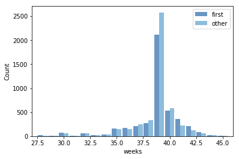

```python
width = 0.45
thinkplot.PrePlot(2)
thinkplot.Hist(first_hist, align='right', width=width)
thinkplot.Hist(other_hist, align='left', width=width)
thinkplot.Config(xlabel='weeks', ylabel='Count', xlim=[27, 46])
```

Series provides methods to compute summary statistics:

```python
mean = live.prglngth.mean()
var = live.prglngth.var()
std = live.prglngth.std()
```

Here are the mean and standard deviation:

```python
mean, std
```

```
(38.56055968517709, 2.702343810070587)
```

Here's are the mean pregnancy lengths for first babies and others:

```python
firsts.prglngth.mean(), others.prglngth.mean()
```

```
(38.600951733514613, 38.522914466737063)
```

And here's the difference (in weeks):

```python
firsts.prglngth.mean() - others.prglngth.mean()
```

```
0.078037266777549519
```

# HomeWork-1 (Due Date 27.03.2018 23:59)

- Read NSFG respondent data with .ReadFemResp() function that provided by nsfg.py and assign it a variable that called resp. Show the columns and then show the first 20 and last 30 rows of resp dataframe and lastly print a sentences that show the number of rows and columns in this resp dataframe. For example, "There are .. rows and .. columns" (2 pts.)
- Select the "agescrn" column from resp and print the value counts. How old are the youngest and oldest respondents(column taht called "agescrn") ? (2 pts.)
- From the resp dataframe, find the rows, patients who are 25 and under 25 years old(column taht called "agescrn") then compute average of the Pregnancies in lifetime (column that called "numpregs") of those patients. (2 pts.)
- From the resp dataframe, find the respondents' number of mariage (column that called "fmarno") and find frequencies for each number of mariage and print the values with sorted by number of mariage (tip: with value_counts() function may help) then Make a histogram from fmarno the number of mariage that done by respondents. To interpret the codes for fmarno column see the [This website](https://www.icpsr.umich.edu/nsfg6/Controller?displayPage=labelDetails&fileCode=FEM§ion=R&subSec=7870&srtLabel=607165) (2 pts.)
- Separate the respondents two group by number of mariage(use fmarno column) and assign them to variables that called neverMarried and married. If respondent's number of mariage is 0 assign them into neverMarried variable, If respondent's number of mariage is 1 and higher than 1 assign them into married variable. Create a histogram that shows the total income for the respondent's family(use totincr column) that contain these two variables in one histogram but show them with different bar(column, bin) for each group by income category these two variables must be next-by-next. (2 pt)
- Find the minumum, maximum, standard deviation, variance and mean of neverMarried and married respondents' total income and print them in a sentence for each variable. (2 pt)

#### Note that: There are 6 question and total of points is 12 but maximum points that can be get 10 points (2 points bonus). Do not forget the give the name to your histogram labels(histogram's label, x-axis and y-axis label), and width of the histograms' columns must be 0.5. In addition, Your answers/codes must be uploaded to your github accounts inside a folder that called Homework1_{YourNameSurname}. The due date is the end of the next Tuesday(27.03.2018 23:59). And you have to send me link of your github account via email.

### There will be no office hour for homeworks. The only chance in order to ask your questions about homework is 1 hour class time. If you have questions about homework you have to come 1 hour class in Tuesday

# ANY LATE UPLOAD TO GITHUB EVEN INCLUDING 1 MINUTE WILL NOT BE ACCEPTED AND HOMEWORKS HAVE TO BE UPLOADED TO ONLY GITHUB. JUST SEND ME YOUR GITHUB ACCOUNT LINK VIA EMAIL. ANY OTHER OPTIONS THAN THESE WILL NOT BE ACCEPTABLE